# Relatório Assessoria 1

Amanda Macedo, Lucas Barbieri, Rodrigo Fonseca e Silvana Schneider

2024-04-17

# Relatório Estatístico - Projeto de Pesquisa: Relações de Trabalho e os servidores com deficiência na Universidade Federal de Santa Maria (UFSM)

## Introdução

O presente relatório apresenta uma análise de dados descritiva e exploratória relativa aos dados obtidos via formulário referente ao projeto de pesquisa Relações de Trabalho e os servidores com deficiência na Universidade Federal de Santa Maria (UFSM). O objetivo geral é entender qual o significado do trabalho para os servidores com deficiência na Universidade Federal de Santa Maria (UFSM) e como o capacitismo interfere nas relações laborais desses servidores. Para concretizar o objetivo geral, o presente estudo almeja realizar os seguintes objetivos específicos:

- Mapear os servidores com deficiência na UFSM;
- Compreender como se dão suas relações de trabalho na organização e se essas são ou já foram permeadas pelo capacitismo;
- Entender qual o significado do trabalho para os servidores com deficiência na UFSM;
- Propor alternativas e indicadores para que a área de gestão de pessoas possa facilitar a inclusão de servidores com deficiência nas relações de trabalho.

## Materiais e métodos

São 54 variáveis, referentes às 54 perguntas contidas no formulário preenchido pelos servidores (a última pergunta referente ao e-mail foi ocultada). Com base nos dados coletados dessas variáveis, serão apresentados neste estudo estatísticas descritivas, incluindo gráficos de barra que salientam a relação entre algumas das variáveis, e testes qui-quadrado para comparações entre variáveis categóricas. Todas as análises foram realizadas em R (R version 4.3.3 (2024-02-29), com os pacotes base, pacman, gridExtra, dplyr, knitr, rmarkdown, ggplot2, kableExtra, stringi, xlsx, readxl, crosstable, flextable e tidyverse.  
As perguntas estão abaixo acompanhadas do nome da variável que as contém:

- Gênero (*genero*)
- Outro Gênero? (*genero_outro*)
- Idade: (*idade*)
- Estado civil: (*estado_civil*)
- Outro Estado civil? (*outro_estado_civil*)
- Tem filhos(as)? (*filhos*)
- Quantos: (*qtd_filhos*)
- Idade(s): (*idade_filhos*)
- Mora com (mais de uma opção pode ser marcada): (*mora_com*)
- Outro Mora com? (*outro_mora_com*)
- Escolaridade: (*escolaridade*)
- Qual(is) curso(s)/área(s) de conhecimento da(s) sua(s) formação(ões)? (*curso_formacao*)
- Categoria: (*categoria*)
- Cargo: (*cargo*)
- Nível: *(cargo_nivel1)*
- Nível: (*cargo_nivel2*)
- Carga horária semanal: (*carga_horaria_semanal*)
- Outro Carga horária semanal? (*outro_carga_horaria_semanal*)
- Unidade de lotação: (*unidade_lotacao*)
- Possui Cargo de Direção (CD) ou Função Gratificada (FG)? (*cd_ou_fg*)
- Campus: (*campus*)
- Ano de ingresso como servidor na Universidade: (*ano_ingresso*)
- Ingressou por intermédio do sistema de cotas para PCD? (*ingresso_cotas_pcd*)
- Você se sente satisfeito/realizado/reconhecido/útil no seu local de trabalho? (*sentimento_local_trabalho*)
- Tipo de deficiência que possui: (*deficiencia*)
- Outro Tipo de deficiência? (*deficiencia_outro*)
- Possui o diagnóstico desde: (*periodo_diagnostico*)
- Causa: (*causa_deficiencia*)
- Você utiliza alguma tecnologia assistiva/recurso? (*uso_tecnologia_assistiva_recurso*)
- Qual(is) tecnologia assistiva/recurso?? (*qual_tecnologia*)
- Se utiliza alguma tecnologia assistiva/recurso, essa é disponibilizada pela UFSM? (*tecnologia_disponibilizada_ufsm*)
- Se não, como você consegue obter (através de recursos próprios, doações, etc)? (*como_consegue_obter_tecnologia*)
- Você necessita de algum acompanhamento ou apoio de outra pessoa para realizar as atividades cotidianas no ambiente de trabalho? (necessita_acompanhamento/*apoio_atividades_cotidianas_notrabalho*)
- Se necessita, em quais atividades? (*se_sim_quais_atividades*?)
- Esse acompanhamento/apoio é disponibilizado pela UFSM? (acompanhamento/*apoio_disponibilizado_ufsm*)
- Se não, como você consegue obter? (*se_nao_como_consegue_obter*)
- De um modo geral, como você considera o nível de acessibilidade arquitetônica da UFSM (Exemplos: rampas, elevadores e banheiros adaptados, calçadas com piso tátil, vagas reservadas em estacionamentos, etc)? (*como_considera_acessibilidade_arquitetonica_ufsm*)
- De um modo geral, como você considera o nível de acessibilidade atitudinal da UFSM (incentivo a percepções sem preconceitos, discriminações e estigmas)? (*como_considera_acessibilidade_atitudinal_ufsm*)
- De um modo geral, como você considera o nível de acessibilidade instrumental/digital da UFSM (Ex: software de leitor de tela no computador, sites e aplicativos institucionais acessíveis e ferramentas que eliminem barreiras digitais e de instrumentos de trabalho)? (*como_considera_acessibilidade_instrumental_digital_ufsm*)
- De um modo geral, como você considera o nível de acessibilidade comunicacional da UFSM (oferecimento de recursos e atividades que promovam a independência no acesso a qualquer conteúdo. Isso inclui legendas, áudios, descrições, Libras, braile, etc)? (*como_considera_acessibilidade_comunicacional_ufsm*)
- Você conhece a legislação brasileira sobre acessibilidade? (*conhece_legislacao_br_sobre_acessibilidade*)
- Qual seu objetivo quando fez o concurso para a UFSM (mais de uma opção pode ser marcada)? (*objetivo_quando_fez_concurso_ufsm*)
- Qual(is) outros objetivos? (*outro_objetivo_quando_fez_concurso_ufsm*)
- Você sentiu dificuldade de adaptação durante o ingresso nas atividades laborais na UFSM? (*dificuldade_adaptacao_durante_ingresso_atividades_laborais_ufsm*)
- Se sim, poderia relatar? Como foi resolvido? (*dificuldade_adaptacao_se_sim_como_foi_resolvido*)
- Você enfrentou algum problema de relacionamento interpessoal com chefias e/ou colegas? (*enfrentou_problema_relacionamento_chefia_eou_colegas*)
- Se sim, poderia relatar? Como foi resolvido? (*problema_relacionamento_se_sim_como_foi_resolvido*)
- Você já foi parte reclamante, na UFSM, em algum Processo administrativo disciplinar (PAD), Sindicância e/ou reclamatória trabalhista? (*ja_foi_parte_reclamante_processo_administrativo_disciplinar_sindicancia_eou_reclamatoria_trabalhista_naufsm*)
- Você considera que a UFSM dispõe de recursos humanos e materiais suficientes para atender necessidades que possam eventualmente surgir relacionadas a acessibilidade? (*considera_ufsm_dispoe_recursos_humanos_materiais_suficientes_atender_necessidades_que_eventualmente_surjam_em_relacao_acessibilidade*)
- Se não, poderia relatar o que considera insuficiente? (*se_nao_relate_oq_considera_insuficiente*)
- Você participa de alguma associação, sindicato, ou outros grupos de luta por defesa de direitos trabalhistas? (*voce_participa_associacao/sindicato/outros_grupos_luta_direitos_trabalhistas*)
- Se sim, qual? (*se_sim_qual_associacao/sindicato*)
- Se participa, você sente que as pautas das PCD são consideradas nas ações dessa associação/sindicato/grupo? (*se_participa_sente_pautas_pcd_consideradas_em_acoes_da_associacao*/*sindicato*)
- Espaço para outros comentários e informações que você queira nos passar sobre inclusão e acessibilidade na UFSM: (*espaco_comentarios*)

## Análise Descritiva

Nesta seção iremos desenvolver as seguintes análises:

- Gênero X grau de satisfação (em todas as questões de acessibilidade)
- Campi x grau de satisfação (em todas as questões de acessibilidade)
- Idade X grau de satisfação (em todas as questões de acessibilidade)
- Tipos de deficiência mais comum X grau de satisfação (em todas as questões de acessibilidade)
- Data de ingresso X entrada por cotas
- Idade X conhecimento da legislação
- Satisfação geral X tempo de serviço
- Satisfação geral X escolaridade
- Satisfação geral X cargo
- Objetivo de fazer o concurso X grau de satisfação (em todas as questões de acessibilidade)
- Objetivo de fazer o concurso X satisfação geral

### Gênero x Grau de satisfação para questões de acessibilidade

Na nossa base de dados temos o mesmo número de pessoas no sexo feminino e masculino, ambos com 32 pessoas. Abaixo temos o gráfico de barras que mostra a quantidade de respostas em cada nível para cada gênero para questões de opinião em relação à acessibilidade.

Em relação acessibilidade arquitetônica da UFSM (Exemplos: rampas, elevadores e banheiros adaptados, calçadas com piso tátil, vagas reservadas em estacionamentos, etc), os homens parecem estar mais satisfeitos do que as mulheres, em geral. Cerca de 37,5% das mulheres responderam bom ou ótimo e, para os homens, este percentual fica em 46,9%.

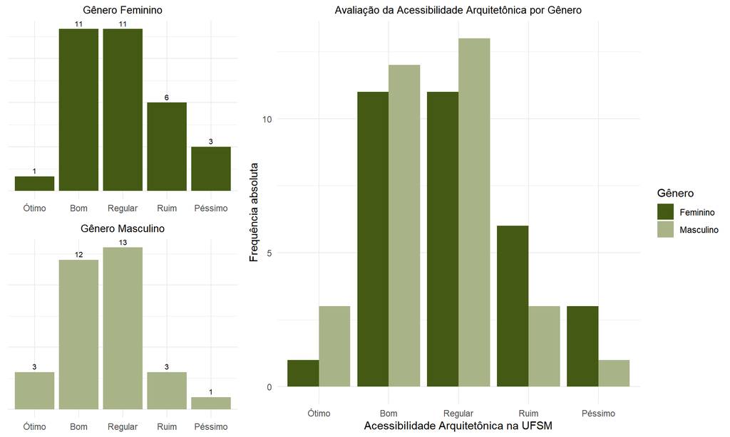

Em relação acessibilidade instrumental/digital da UFSM (Ex: software de leitor de tela no computador, sites e aplicativos institucionais acessíveis e ferramentas que eliminem barreiras digitais e de instrumentos de trabalho), os homens também parecem estar mais satisfeitos do que as mulheres, em geral. Cerca de 37,5% das mulheres responderam bom ou ótimo e, para os homens, este percentual fica em 50%.

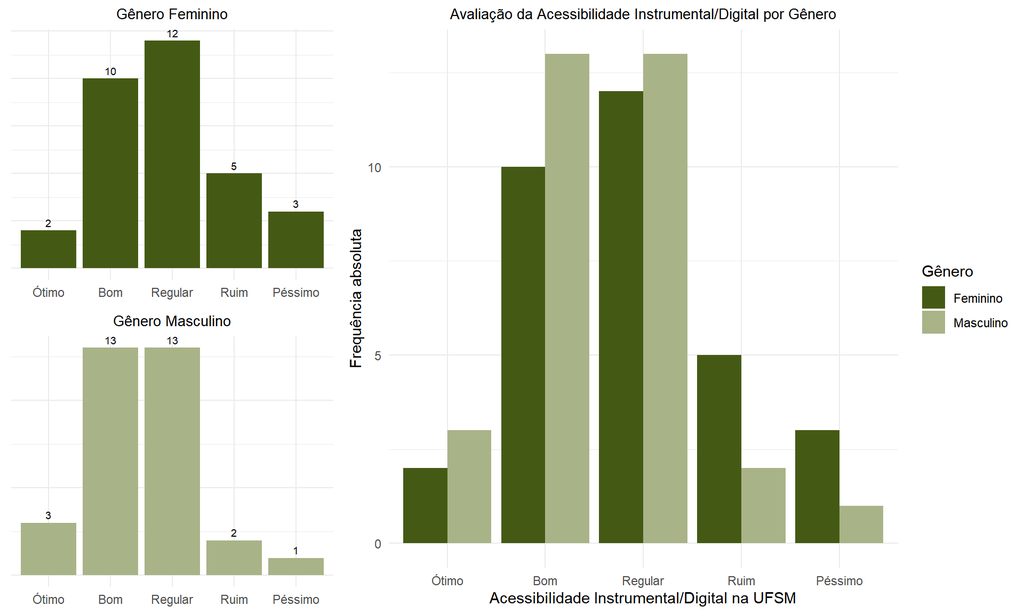

Em relação acessibilidade atitudinal da UFSM (incentivo a percepções sem preconceitos, discriminações e estigmas), os homens novamnete se mostram mais satisfeitos do que as mulheres, em geral. Cerca de 43,8% das mulheres responderam bom ou ótimo e, para os homens, este percentual fica em 59,4%.

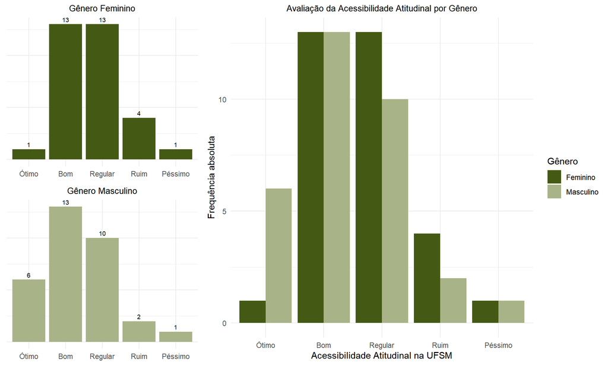

Em relação acessibilidade comunicacional da UFSM (oferecimento de recursos e atividades que promovam a independência no acesso a qualquer conteúdo. Isso inclui legendas, áudios, descrições, Libras, braile, etc), os homens novamnete se mostram mais satisfeitos do que as mulheres, em geral. Cerca de 28,1% das mulheres responderam bom ou ótimo e, para os homens, este percentual fica em 56,2%.

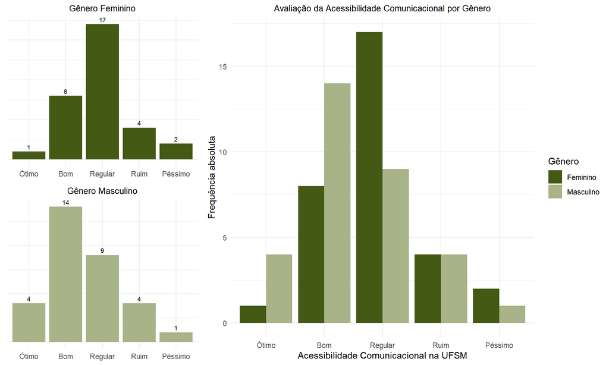

Agora, montamos uma tabela cruzada juntando as acessibilidades em apenas uma coluna, para realizarmos o teste de Qui-Quadrado para conferir a independência entre variáveis, faremos isso também com todos os próximos cruzamentos.  
No caso da Qui-Quadrado, estatística de teste seria o grau de concordância da nossa amostra, com a hipótese de que as variáveis são independentes; ou não possuem associação. E o p-valor é a probabilidade de que a associação entre as variáveis da amostra é ao acaso, usando 0,05 como valor crítico. A estatística de teste é o valor 11,535 e seu p-valor é 0,02116. Usando o nível de significância de 5%, e 4 graus de liberdade, a estatística de teste entra num valor crítico, e com o p-valor abaixo dos 0,05. Podemos então considerar que o gênero afeta na opinião sobre acessibilidade.

| label | variable | Acessibilidade Geral Ótimo | Acessibilidade Geral Bom | Acessibilidade Geral Regular | Acessibilidade Geral Ruim | Acessibilidade Geral Péssimo | Total |  |
| --- | --- | --- | --- | --- | --- | --- | --- | --- |
| Gênero | Feminino | 5 (3.91%) | 42 (32.81%) | 53 (41.41%) | 19 (14.84%) | 9 (7.03%) |  | 128 (50.00%) |
|  | Masculino | 16 (12.50%) | 52 (40.62%) | 45 (35.16%) | 11 (8.59%) | 4 (3.12%) | 128 (50.00%) |  |
|  | Total | 21 (8.20%) | 94 (36.72%) | 98 (38.28%) | 30 (11.72%) | 13 (5.08%) | 256 (100.00%) |  |

### Campi x Grau de satisfação para questões de acessibilidade

Na nossa base de dados temos 59 pessoas do campus de Santa Maria, 3 de Cachoeira do Sul, 1 de Frederico Westphalene 1 de Palmeira das Missões. Abaixo temos o gráfico de barras que mostra a quantidade de respostas em cada nível para cada campus para questões de opinião em relação à acessibilidade. Primeiro vamos olhar pros resultados dos servidores de Santa Maria, já que são a maioria na nossa base.

Em relação às questões de acessibilidade da UFSM para servidores de Santa Maria, vemos que a maioria fica entre bom e regular. Porém, olhando para o percentual de respostas Ruim ou Péssimo, a acessibilidade arquitetônica tem 20.3% e a atitudinal é de 11.9%. Isso indica que os servidores possam estar mais insatisfeito com questões relacionadas a rampas, elevadores e banheiros adaptados e etc, do que com questões de incentivo a percepções sem preconceitos, discriminações, estigmas e etc.

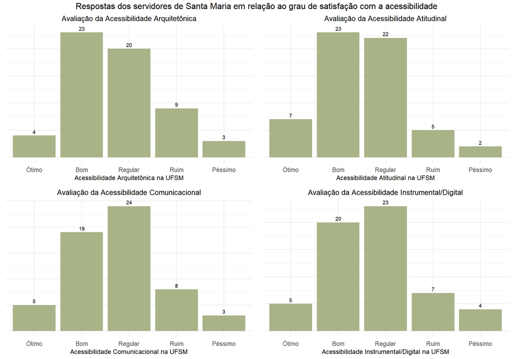

Como os demais campus tem poucos servidores participantes da pesquisa o resumo de suas respostas em relação a satisfação da acessibilidade estarão na tabela abaixo, juntamente com o resumo do campus Santa Maria. Avaliando as respostas individualmente, o campus de Cachoeira do Sul obteve Bom como a maioria de suas respostas às perguntas de acessibilidade (58,33%). O servidor do campus de Frederico Westphalen repondeu duas perguntas com Bom e duas com Regular. Já o servidor de Palmeira das Missões repondeu com Regular para todas as perguntas. E os servidores de Santa Maria responderam pra maioria das questões Regular (37,71%).  
Pela tabela cruzada, vemos que amostragem em dois dos Campi são extremamente baixas, visando isso, um teste para associação entre as variáveis não parece muito viável.

| label | variable | Acessibilidade Geral Ótimo | Acessibilidade Geral Bom | Acessibilidade Geral Regular | Acessibilidade Geral Ruim | Acessibilidade Geral Péssimo | Total |  |
| --- | --- | --- | --- | --- | --- | --- | --- | --- |
| Campus | Cachoeira do Sul | 0 (0%) | 7 (58.33%) | 3 (25.00%) | 1 (8.33%) | 1 (8.33%) |  | 12 (4.69%) |
|  | Frederico Westphalen | 0 (0%) | 2 (50.00%) | 2 (50.00%) | 0 (0%) | 0 (0%) | 4 (1.56%) |  |
|  | Palmeira das Missões | 0 (0%) | 0 (0%) | 4 (100.00%) | 0 (0%) | 0 (0%) | 4 (1.56%) |  |
|  | Santa Maria | 21 (8.90%) | 85 (36.02%) | 89 (37.71%) | 29 (12.29%) | 12 (5.08%) | 236 (92.19%) |  |
|  | Total | 21 (8.20%) | 94 (36.72%) | 98 (38.28%) | 30 (11.72%) | 13 (5.08%) | 256 (100.00%) |  |

### Idade X Grau de satisfação para questões de acessibilidade

Temos servidores de 33 a 69 anos na nossa base. Para fazer uma análise desta variável iremos separar as pessoas em faixa etárias e através do método dos quantis, que divide os dados em intervalos de tamanho aproximadamente igual, garantindo uma distribuição uniforme. Desta forma, temos quatro intervalos de dados: [33,40] com 17 pessoas, (40,46] com 19 pessoas, (46,53] com 13 pessoas e (53,69] com 15 pessoas.

Apresentamos abaixo dois gráficos que ilustram a satisfação dos servidores com relação à acessibilidade, divididos por faixa etária. Observa-se que a faixa etária de 46 a 53 anos demonstra maior satisfação na questão comunicacional, em comparação com as outras faixas etárias.

Por outro lado, na questão atitudinal, os resultados são diferentes. A faixa etária de 40 a 46 anos mostra-se mais satisfeita, enquanto a faixa de 46 a 53 anos é a menos satisfeita. Vale ressaltar que ao mencionar ‘mais satisfeito’, estamos comparando o percentual de respostas classificadas como Bom e Ótimo em relação às demais.

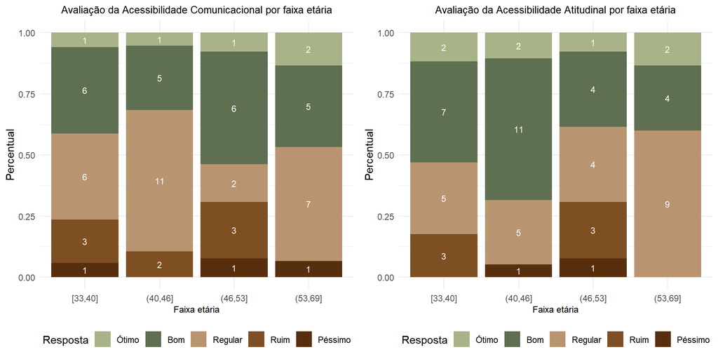

A seguir, apresentamos a satisfação dos servidores em relação à acessibilidade instrumental/digital e arquitetônica. Na questão da acessibilidade instrumental/digital, destaca-se que a faixa etária mais satisfeita é a de 40 a 46 anos. Identificar a faixa etária menos satisfeita é mais desafiador, pois apresentam resultados semelhantes. Em relação à acessibilidade arquitetônica, observa-se que a faixa etária de 46 a 53 anos apresenta as melhores respostas, enquanto a faixa etária de 53 a 69 anos demonstra menos satisfação.

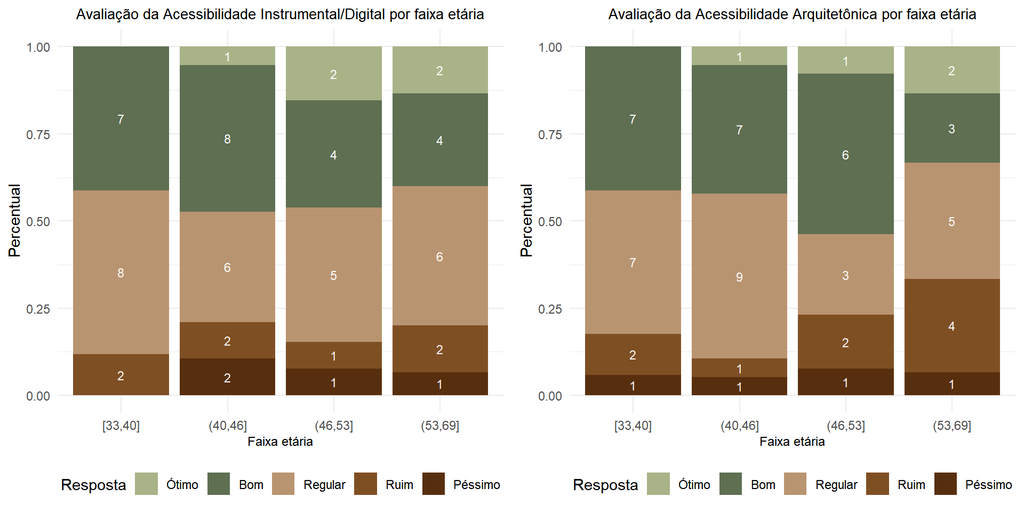

Para a tabela cruzada, podemos ver que há algumas diferenças nas proporções, então a categoria “Ótimo” é maior proporcionalmente entre os servidores de 53 a 69 anos. O teste Qui-Quadrado dá um p-valor de 0,3434, isso nos diz que não há associação significativa entre a idade e a satisfação sobre acessibilidade.

| label | variable | Acessibilidade Geral Ótimo | Acessibilidade Geral Bom | Acessibilidade Geral Regular | Acessibilidade Geral Ruim | Acessibilidade Geral Péssimo | Total |  |
| --- | --- | --- | --- | --- | --- | --- | --- | --- |
| Faixa etária | [33,40] | 3 (4.41%) | 27 (39.71%) | 26 (38.24%) | 10 (14.71%) | 2 (2.94%) |  | 68 (26.56%) |
|  | (40,46] | 5 (6.58%) | 31 (40.79%) | 31 (40.79%) | 5 (6.58%) | 4 (5.26%) | 76 (29.69%) |  |
|  | (46,53] | 5 (9.62%) | 20 (38.46%) | 14 (26.92%) | 9 (17.31%) | 4 (7.69%) | 52 (20.31%) |  |
|  | (53,69] | 8 (13.33%) | 16 (26.67%) | 27 (45.00%) | 6 (10.00%) | 3 (5.00%) | 60 (23.44%) |  |
|  | Total | 21 (8.20%) | 94 (36.72%) | 98 (38.28%) | 30 (11.72%) | 13 (5.08%) | 256 (100.00%) |  |

### Tipo de deficiência mais comum X Grau de satisfação para questões de acessibilidade

O tipo de deficiência mais comum que temos entre os servidores participantes da pesquisa é a deficiência visual (35,94%) como vemos na tabela abaixo.

Quantidade e percentual de servidores com determinados tipos de deficiência

| Tipo de deficiência | Quantidade | Percentual |
| --- | --- | --- |
| Auditiva | 8 | 12.50 |
| Cognitivo/Intelectual | 1 | 1.56 |
| Física ou motora | 16 | 25.00 |
| Múltiplas | 1 | 1.56 |
| Outra | 11 | 17.19 |
| Psicossocial | 3 | 4.69 |
| Visceral | 1 | 1.56 |
| Visual | 23 | 35.94 |

Em relação às questões de acessibilidade para os servidores com deficiência visual, observamos os gráficos abaixo. A acessibilidade comunicacional e a instrumental/digital foram avaliadas de forma bastante parecida. Ambas tiveram a maioria das avaliações em Regular (12) e em segundo lugar Bom (6), com o mesmo número. A avaliação da acessibilidade atitudinal teve mais respostas Ótimo do que as demais questões, e a mesma proporção de respostas em Bom e Regular. Sobre a acessibilidade arquitetônica os servidores a resposta mais frequente foi Regular (10) e em seguida, Bom (8).

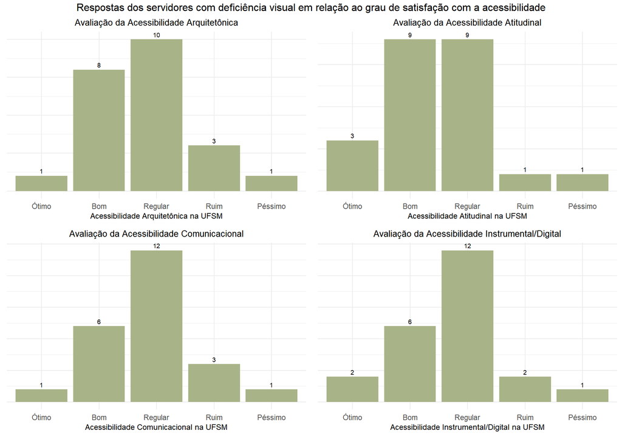

Incluímos na tabela abaixo a quantidade/percentual agrupado das demais deficiências menos comuns. Os servidores com deficiência visual marcaram a maioria das questões com Regular (46,74%) e em segundo lugar Bom (31,52%). Os servidores portadores da segunda deficiência mais comum, a Física ou Motora, marcaram mais a opção Bom (50%) e em segundo Regular (39,06%).

| label | variable | Acessibilidade Geral Ótimo | Acessibilidade Geral Bom | Acessibilidade Geral Regular | Acessibilidade Geral Ruim | Acessibilidade Geral Péssimo | Total |  |
| --- | --- | --- | --- | --- | --- | --- | --- | --- |
| Deficiencia | Auditiva | 6 (18.75%) | 5 (15.62%) | 12 (37.50%) | 6 (18.75%) | 3 (9.38%) |  | 32 (12.50%) |
|  | Cognitivo/Intelectual | 0 (0%) | 2 (50.00%) | 2 (50.00%) | 0 (0%) | 0 (0%) | 4 (1.56%) |  |
|  | Física ou motora | 4 (6.25%) | 32 (50.00%) | 25 (39.06%) | 2 (3.12%) | 1 (1.56%) | 64 (25.00%) |  |
|  | Múltiplas | 0 (0%) | 1 (25.00%) | 1 (25.00%) | 2 (50.00%) | 0 (0%) | 4 (1.56%) |  |
|  | Outra | 4 (9.09%) | 21 (47.73%) | 9 (20.45%) | 6 (13.64%) | 4 (9.09%) | 44 (17.19%) |  |
|  | Psicossocial | 0 (0%) | 3 (25.00%) | 5 (41.67%) | 4 (33.33%) | 0 (0%) | 12 (4.69%) |  |
|  | Visceral | 0 (0%) | 1 (25.00%) | 1 (25.00%) | 1 (25.00%) | 1 (25.00%) | 4 (1.56%) |  |
|  | Visual | 7 (7.61%) | 29 (31.52%) | 43 (46.74%) | 9 (9.78%) | 4 (4.35%) | 92 (35.94%) |  |
|  | Total | 21 (8.20%) | 94 (36.72%) | 98 (38.28%) | 30 (11.72%) | 13 (5.08%) | 256 (100.00%) |  |

### Data de ingresso X Entrada por cotas

Observando o número de servidores com deficiência que ingressaram na UFSM por ano, notamos que 2016 registrou o maior número de ingressantes, com 8 pessoas, seguido por 2014, com 5 pessoas. Ao lado, apresentamos um gráfico de pizza que ilustra a proporção de servidores que ingressaram por meio de cotas para pessoas com deficiência na UFSM. Da amostra de 64 participantes da pesquisa, a maioria, 45 pessoas (70,31%), ingressou sem cotas.

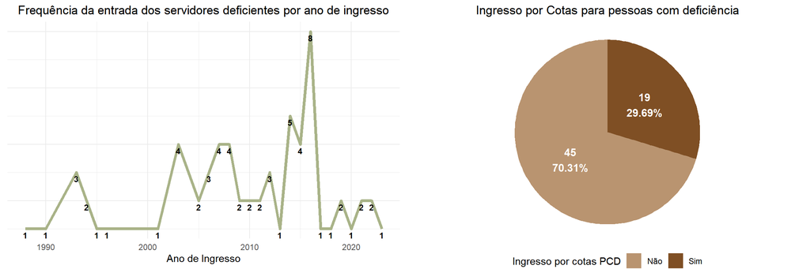

Devido à falta de uma amostra substancial por ano de ingresso, optaremos por agrupar os indivíduos em intervalos de ano de entrada. Seguiremos a abordagem dos quantis para essa divisão, que segmenta os dados em intervalos de tamanho aproximadamente igual. Na tabela abaixo, apresentamos a distribuição dos grupos, a quantidade de servidores em cada um e os respectivos percentuais de entrada por cota ou sem cota.

| label | variable | Intervalo de ano de ingresso na UFSM [1988,2006] | Intervalo de ano de ingresso na UFSM (2006,2011] | Intervalo de ano de ingresso na UFSM (2011,2016] | Intervalo de ano de ingresso na UFSM (2016,2023] | Total |  |
| --- | --- | --- | --- | --- | --- | --- | --- |
| Ingresso por cotas PCD | Não | 13 (28.89%) | 15 (33.33%) | 12 (26.67%) | 5 (11.11%) |  | 45 (70.31%) |
|  | Sim | 3 (15.79%) | 2 (10.53%) | 9 (47.37%) | 5 (26.32%) | 19 (29.69%) |  |
|  | Total | 16 (25.00%) | 17 (26.56%) | 21 (32.81%) | 10 (15.62%) | 64 (100.00%) |  |

Ainda utilizando o método do Qui-Quadrado com 5% de significância, obtivemos: 0,06421 para o p-valor. Dado que excedemos o limite de significância, devemos considerar que não há associação significativa entre as variáveis, ou seja, a data de ingresso não está relacionada a entrada por cotas.

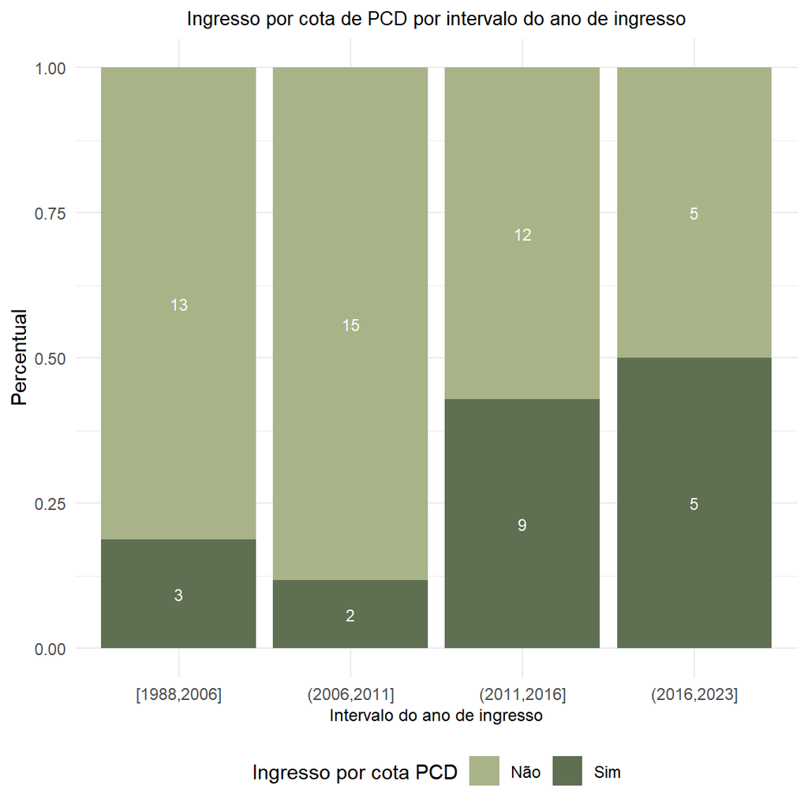

### Idade X Conhecimento da legislação

Na tabela abaixo, observa-se que a maioria dos servidores com deficiência declara conhecer a legislação brasileira sobre acessibilidade (48,44%). O segundo maior grupo respondeu que “não conhece nem desconhece” (25%). Ao agruparmos as respostas “conheço” e “conheço totalmente”, totalizam mais da metade dos servidores (56,25%). Portanto, aparentemente, a maioria deles está familiarizada com a legislação.

| label | variable | Faixa etária [33,40] | Faixa etária (40,46] | Faixa etária (46,53] | Faixa etária (53,69] | Total |  |
| --- | --- | --- | --- | --- | --- | --- | --- |
| Conhecimento legislação brasileira sobre acessibilidade | conheço totalmente | 1 (20.00%) | 0 (0%) | 4 (80.00%) | 0 (0%) |  | 5 (7.81%) |
|  | conheço | 10 (32.26%) | 7 (22.58%) | 4 (12.90%) | 10 (32.26%) | 31 (48.44%) |  |
|  | não conheço nem desconheço | 4 (25.00%) | 7 (43.75%) | 2 (12.50%) | 3 (18.75%) | 16 (25.00%) |  |
|  | desconheço | 2 (20.00%) | 4 (40.00%) | 2 (20.00%) | 2 (20.00%) | 10 (15.62%) |  |
|  | desconheço totalmente | 0 (0%) | 1 (50.00%) | 1 (50.00%) | 0 (0%) | 2 (3.12%) |  |
|  | Total | 17 (26.56%) | 19 (29.69%) | 13 (20.31%) | 15 (23.44%) | 64 (100.00%) |  |

Após a realização do teste, verificamos que o p-valor equivale a 0,09582, assim excedendo o nível de significância de 0,05; então podemos dizer que a faixa etária não afeta no conhecimento sobre a legislação sobre acessibilidade.

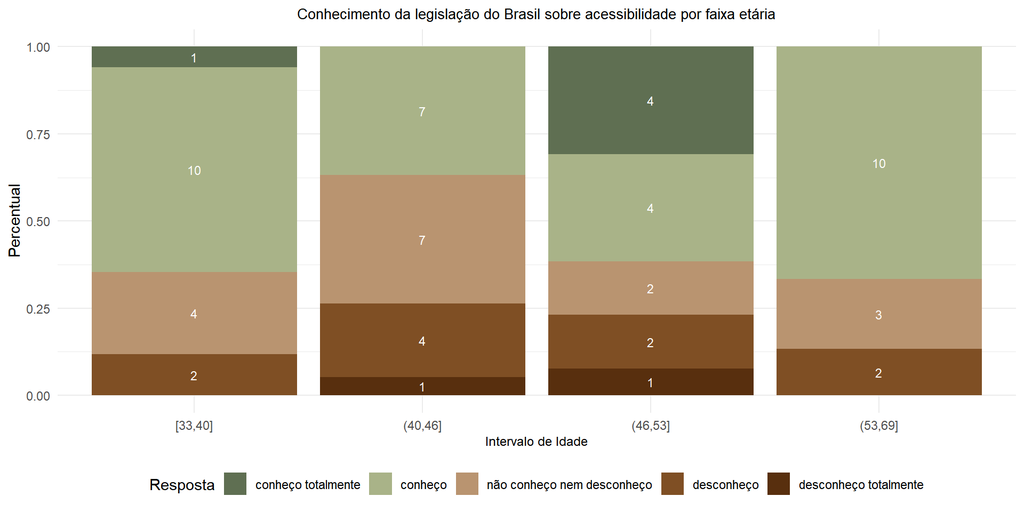

### Satisfação geral x Tempo de serviço

Assim como ocorre com a amostra de ano de ingresso, enfrentamos uma limitação semelhante em relação ao tempo de serviço dos servidores (uma variável derivada do ano de ingresso). Por essa razão, optaremos por agrupar os indivíduos em intervalos de tempo de serviço. Novamente, adotaremos a abordagem dos quantis para essa divisão, que segmenta os dados em intervalos de tamanho aproximadamente igual.

Em nossa base de dados, encontramos pessoas com períodos de serviço variando de 1 a 36 anos na UFSM, conforme demonstrado na tabela abaixo, que apresenta a distribuição dos grupos cruzados com a satisfação no local de trabalho. Observa-se que, em termos de satisfação, a maioria dos servidores se declara satisfeita (43,75%), seguida por aqueles que se sentem muito satisfeitos (21,88%).

| label | variable | Você se sente satisfeito/realizado/reconhecido/útil no local de trabalho? [0,8] | Você se sente satisfeito/realizado/reconhecido/útil no local de trabalho? (8,13] | Você se sente satisfeito/realizado/reconhecido/útil no local de trabalho? (13,18] | Você se sente satisfeito/realizado/reconhecido/útil no local de trabalho? (18,36] | Total |  |
| --- | --- | --- | --- | --- | --- | --- | --- |
| Sentimento no local de trabalho | totalmente satisfeito | 5 (50.00%) | 1 (10.00%) | 1 (10.00%) | 3 (30.00%) |  | 10 (15.62%) |
|  | muito satisfeito | 2 (14.29%) | 1 (7.14%) | 6 (42.86%) | 5 (35.71%) | 14 (21.88%) |  |
|  | satisfeito | 9 (32.14%) | 8 (28.57%) | 4 (14.29%) | 7 (25.00%) | 28 (43.75%) |  |
|  | pouco satisfeito | 1 (12.50%) | 3 (37.50%) | 4 (50.00%) | 0 (0%) | 8 (12.50%) |  |
|  | nada satisfeito | 1 (25.00%) | 2 (50.00%) | 0 (0%) | 1 (25.00%) | 4 (6.25%) |  |
|  | Total | 18 (28.12%) | 15 (23.44%) | 15 (23.44%) | 16 (25.00%) | 64 (100.00%) |  |

O teste feito usando a tabela cruzada nos dá um p-valor equivalente a 0,01899, sendo menor que o nível de significância, então consideramos que o tempo de serviço afeta no sentimento sobre o local de trabalho significamente.Porém, olhando o gráfico, podemos ver que as pessoas que estão na Universidade entre 8 e 13 anos possuem a menor proporção de totalmente e muito satisfeito; e possui a maior quantidade de insatisfeitos.

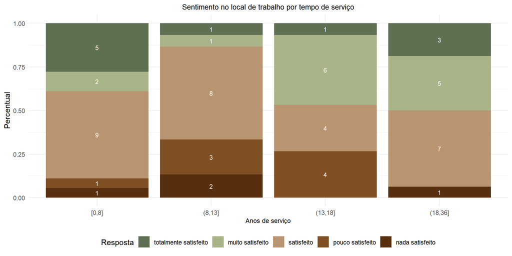

### Satisfação geral X Escolaridade

Abaixo, encontram-se as informações sobre a escolaridade dos servidores e sua satisfação no local de trabalho. Observa-se que a maioria dos servidores possui doutorado (34,38%), seguido por pós-graduação lato sensu (31,25%). Em terceiro lugar, encontramos servidores com mestrado (20,31%), seguidos por aqueles com ensino superior completo (7,81%). A minoria dos servidores possui ensino superior incompleto (6,25%).

| label | variable | Escolaridade Doutorado | Escolaridade Ensino Superior completo | Escolaridade Ensino superior incompleto | Escolaridade Mestrado | Escolaridade Pós-Graduação lato sensu (especialização) | Total |  |
| --- | --- | --- | --- | --- | --- | --- | --- | --- |
| Sentimento no local de trabalho | totalmente satisfeito | 4 (40.00%) | 0 (0%) | 1 (10.00%) | 4 (40.00%) | 1 (10.00%) |  | 10 (15.62%) |
|  | muito satisfeito | 6 (42.86%) | 1 (7.14%) | 1 (7.14%) | 2 (14.29%) | 4 (28.57%) | 14 (21.88%) |  |
|  | satisfeito | 9 (32.14%) | 2 (7.14%) | 2 (7.14%) | 5 (17.86%) | 10 (35.71%) | 28 (43.75%) |  |
|  | pouco satisfeito | 1 (12.50%) | 2 (25.00%) | 0 (0%) | 1 (12.50%) | 4 (50.00%) | 8 (12.50%) |  |
|  | nada satisfeito | 2 (50.00%) | 0 (0%) | 0 (0%) | 1 (25.00%) | 1 (25.00%) | 4 (6.25%) |  |
|  | Total | 22 (34.38%) | 5 (7.81%) | 4 (6.25%) | 13 (20.31%) | 20 (31.25%) | 64 (100.00%) |  |

Realizando o Qui-Quadrado, obtivemos um p-valor de 0,7353, assim não há associação significativa entre a satisfação no trabalho e a Escolaridade, pois está acima do nível de significância. E os gráficos mostram que a proporção está bem distribuída, mesmo considerando as colunas que possuem poucos servidores.

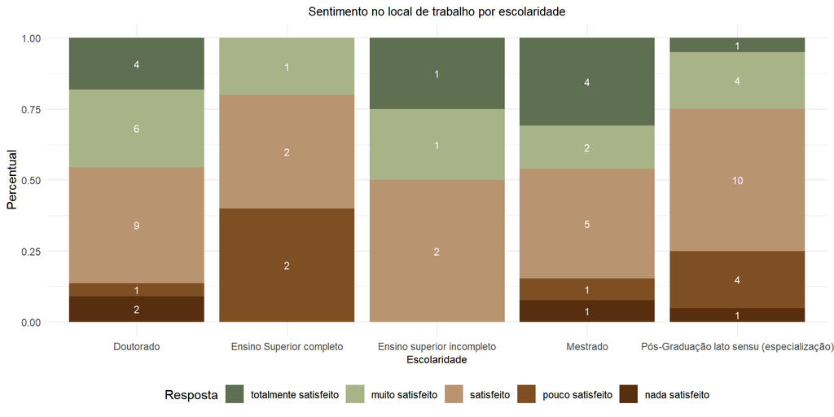

### Satisfação geral X Cargo

Observamos que a maioria dos servidores é composta por técnicos administrativos em educação (79,69%), enquanto os docentes representam a minoria (20,31%). Na tabela abaixo, notamos que a maior parte dos servidores docentes declara-se satisfeita ou muito satisfeita (69,23%), o que também se aplica aos técnicos administrativos (64,71%). O teste usando a tabela cruzada, nos dá um p-valor de 0,6277, sendo acima do nível de significância, então podemos considerar que não há associação significativa entre a categoria do servidor e seu sentimento sobre o local de trabalho.

| label | variable | Você se sente satisfeito/realizado/reconhecido/útil no local de trabalho? totalmente satisfeito | Você se sente satisfeito/realizado/reconhecido/útil no local de trabalho? muito satisfeito | Você se sente satisfeito/realizado/reconhecido/útil no local de trabalho? satisfeito | Você se sente satisfeito/realizado/reconhecido/útil no local de trabalho? pouco satisfeito | Você se sente satisfeito/realizado/reconhecido/útil no local de trabalho? nada satisfeito | Total |  |
| --- | --- | --- | --- | --- | --- | --- | --- | --- |
| Categoria | Docente | 3 (23.08%) | 4 (30.77%) | 5 (38.46%) | 1 (7.69%) | 0 (0%) |  | 13 (20.31%) |
|  | Técnico Administrativo em Educação | 7 (13.73%) | 10 (19.61%) | 23 (45.10%) | 7 (13.73%) | 4 (7.84%) | 51 (79.69%) |  |
|  | Total | 10 (15.62%) | 14 (21.88%) | 28 (43.75%) | 8 (12.50%) | 4 (6.25%) | 64 (100.00%) |  |

### Objetivo de fazer o concurso X Grau de satisfação para questões de acessibilidade

A maioria dos servidores que participaram da pesquisa citaram que tinham como objetivo (ou um dos objetivos) a realização profissional quando fizeram o concurso da UFSM (68,75%). Em segundo lugar, citam independência financeira (67,19%), em terceiro realização pessoal (53,12%), em quarto contribuir socialmente (32,81%) e em último outros (9,38%).

Quantidade e percentual de servidores e seus objetivos de quando realizaram o concurso da UFSM

| Objetivo quando fez o concurso da UFSM | Quantidade | Percentual |
| --- | --- | --- |
| Outro | 6 | 9.38 |
| contribuir socialmente | 21 | 32.81 |
| independência financeira | 43 | 67.19 |
| realização pessoal | 34 | 53.12 |
| realização profissional | 44 | 68.75 |

Na tabela abaixo vemos o cruzamento das informações de objetivo de quando fez o concurso da UFSM e satisfação da acessibilidade comunicacional. A maioria dos servidores que citaram como objetivo contribuir socialmente e/ou independência financeira e/ou outro marcaram Regular. Já os servidores que citaram realização pessoal marcaram mais a opção Bom (44,12%). Enquanto os servidores que citaram como objetivo realização profissional marcaram na mesma proporção Bom e Regular (36,36%).

Usando o Qui-Quadrado, obtivemos um p-valor de 0,9564, sendo acima do nível de significância, podemos considerar que não há associação entre o objetivo e a opinião sobre a acessibilidade comunicacional.

| label | variable | Acessibilidade Comunicacional Ótimo | Acessibilidade Comunicacional Bom | Acessibilidade Comunicacional Regular | Acessibilidade Comunicacional Ruim | Acessibilidade Comunicacional Péssimo | Total |  |
| --- | --- | --- | --- | --- | --- | --- | --- | --- |
| Objetivos de quando realizaram o concurso da UFSM | contribuir socialmente | 0 (0%) | 8 (38.10%) | 10 (47.62%) | 2 (9.52%) | 1 (4.76%) |  | 21 (14.19%) |
|  | independência financeira | 3 (6.98%) | 13 (30.23%) | 21 (48.84%) | 4 (9.30%) | 2 (4.65%) | 43 (29.05%) |  |
|  | Outro | 0 (0%) | 1 (16.67%) | 3 (50.00%) | 1 (16.67%) | 1 (16.67%) | 6 (4.05%) |  |
|  | realização pessoal | 1 (2.94%) | 15 (44.12%) | 13 (38.24%) | 3 (8.82%) | 2 (5.88%) | 34 (22.97%) |  |
|  | realização profissional | 4 (9.09%) | 16 (36.36%) | 16 (36.36%) | 5 (11.36%) | 3 (6.82%) | 44 (29.73%) |  |
|  | Total | 8 (5.41%) | 53 (35.81%) | 63 (42.57%) | 15 (10.14%) | 9 (6.08%) | 148 (100.00%) |  |

Temos a informação de objetivo quando fez concurso da UFSM e satisfação da acessibilidade atitudinal na tabela abaixo. Na questão atitudinal, servidores que citaram como objetivo Outro e/ou realização pessoal e/ou realização profissional marcaram mais a opção Bom do que as demais. Os servidores que citaram como objetivo independência financeira marcaram igualmente Bom e Regular (41,86%) e quem citou contribuir socialmente marcou mais Regular que as demais opções (47,62%).

| label | variable | Acessibilidade Atitudinal Ótimo | Acessibilidade Atitudinal Bom | Acessibilidade Atitudinal Regular | Acessibilidade Atitudinal Ruim | Acessibilidade Atitudinal Péssimo | Total |  |
| --- | --- | --- | --- | --- | --- | --- | --- | --- |
| Objetivos de quando realizaram o concurso da UFSM | contribuir socialmente | 2 (9.52%) | 7 (33.33%) | 10 (47.62%) | 2 (9.52%) | 0 (0%) |  | 21 (14.19%) |
|  | independência financeira | 3 (6.98%) | 18 (41.86%) | 18 (41.86%) | 4 (9.30%) | 0 (0%) | 43 (29.05%) |  |
|  | Outro | 0 (0%) | 4 (66.67%) | 1 (16.67%) | 1 (16.67%) | 0 (0%) | 6 (4.05%) |  |
|  | realização pessoal | 3 (8.82%) | 16 (47.06%) | 11 (32.35%) | 2 (5.88%) | 2 (5.88%) | 34 (22.97%) |  |
|  | realização profissional | 7 (15.91%) | 17 (38.64%) | 15 (34.09%) | 5 (11.36%) | 0 (0%) | 44 (29.73%) |  |
|  | Total | 15 (10.14%) | 62 (41.89%) | 55 (37.16%) | 14 (9.46%) | 2 (1.35%) | 148 (100.00%) |  |

Na avaliação da acessibilidade arquitetônica, todos os grupos indicaram predominantemente a opção Regular em comparação com as demais (embora aqueles com o objetivo de realização pessoal tenham respondido em proporções semelhantes como Bom e Regular).

| label | variable | Acessibilidade Arquitetônica Ótimo | Acessibilidade Arquitetônica Bom | Acessibilidade Arquitetônica Regular | Acessibilidade Arquitetônica Ruim | Acessibilidade Arquitetônica Péssimo | Total |  |
| --- | --- | --- | --- | --- | --- | --- | --- | --- |
| Objetivos de quando realizaram o concurso da UFSM | contribuir socialmente | 1 (4.76%) | 7 (33.33%) | 8 (38.10%) | 4 (19.05%) | 1 (4.76%) |  | 21 (14.19%) |
|  | independência financeira | 1 (2.33%) | 16 (37.21%) | 18 (41.86%) | 7 (16.28%) | 1 (2.33%) | 43 (29.05%) |  |
|  | Outro | 0 (0%) | 2 (33.33%) | 3 (50.00%) | 0 (0%) | 1 (16.67%) | 6 (4.05%) |  |
|  | realização pessoal | 1 (2.94%) | 13 (38.24%) | 13 (38.24%) | 5 (14.71%) | 2 (5.88%) | 34 (22.97%) |  |
|  | realização profissional | 4 (9.09%) | 15 (34.09%) | 16 (36.36%) | 6 (13.64%) | 3 (6.82%) | 44 (29.73%) |  |
|  | Total | 7 (4.73%) | 53 (35.81%) | 58 (39.19%) | 22 (14.86%) | 8 (5.41%) | 148 (100.00%) |  |

| label | variable | Acessibilidade Instrumental/Digital Ótimo | Acessibilidade Instrumental/Digital Bom | Acessibilidade Instrumental/Digital Regular | Acessibilidade Instrumental/Digital Ruim | Acessibilidade Instrumental/Digital Péssimo | Total |  |
| --- | --- | --- | --- | --- | --- | --- | --- | --- |
| Objetivos de quando realizaram o concurso da UFSM | contribuir socialmente | 0 (0%) | 8 (38.10%) | 8 (38.10%) | 4 (19.05%) | 1 (4.76%) |  | 21 (14.19%) |
|  | independência financeira | 3 (6.98%) | 12 (27.91%) | 21 (48.84%) | 6 (13.95%) | 1 (2.33%) | 43 (29.05%) |  |
|  | Outro | 0 (0%) | 3 (50.00%) | 1 (16.67%) | 0 (0%) | 2 (33.33%) | 6 (4.05%) |  |
|  | realização pessoal | 2 (5.88%) | 12 (35.29%) | 14 (41.18%) | 4 (11.76%) | 2 (5.88%) | 34 (22.97%) |  |
|  | realização profissional | 5 (11.36%) | 14 (31.82%) | 18 (40.91%) | 5 (11.36%) | 2 (4.55%) | 44 (29.73%) |  |
|  | Total | 10 (6.76%) | 49 (33.11%) | 62 (41.89%) | 19 (12.84%) | 8 (5.41%) | 148 (100.00%) |  |

Em relação aos testes das últimas três tabelas, temos os seguintes p-valores: 0,6241 para Atitudinal, 0,9746 para Arquitetônica e 0,3928 para Instrumental/Digital. Sendo todos os p-valores acima do nível de significância, podemos concluir que o objetivo não afeta na opinião dos quatro tipos de acessibilidades representadas no questionário.

### Objetivo de fazer o concurso X Satisfação geral

Abaixo vemos a informação de sentimento de satisfação no local do trabalho e objetivos de quando realizou o concurso da UFSM. Todos os 5 grupos de objetivos tiveram o maior percentual de resposta à questão de satisfação “satisfeito”. Utilizando o teste do Qui-Quadrado, obtemos um p-valor de 0,6712, então podemos dizer que não há associação significativa entre o objetivo de fazer o concurso e a satisfação com o trabalho.

| label | variable | Você se sente satisfeito/realizado/reconhecido/útil no local de trabalho? totalmente satisfeito | Você se sente satisfeito/realizado/reconhecido/útil no local de trabalho? muito satisfeito | Você se sente satisfeito/realizado/reconhecido/útil no local de trabalho? satisfeito | Você se sente satisfeito/realizado/reconhecido/útil no local de trabalho? pouco satisfeito | Você se sente satisfeito/realizado/reconhecido/útil no local de trabalho? nada satisfeito | Total |  |
| --- | --- | --- | --- | --- | --- | --- | --- | --- |
| Objetivos de quando realizaram o concurso da UFSM | contribuir socialmente | 2 (9.52%) | 6 (28.57%) | 9 (42.86%) | 4 (19.05%) | 0 (0%) |  | 21 (14.19%) |
|  | independência financeira | 7 (16.28%) | 8 (18.60%) | 20 (46.51%) | 6 (13.95%) | 2 (4.65%) | 43 (29.05%) |  |
|  | Outro | 1 (16.67%) | 0 (0%) | 4 (66.67%) | 0 (0%) | 1 (16.67%) | 6 (4.05%) |  |
|  | realização pessoal | 5 (14.71%) | 10 (29.41%) | 15 (44.12%) | 4 (11.76%) | 0 (0%) | 34 (22.97%) |  |
|  | realização profissional | 9 (20.45%) | 9 (20.45%) | 21 (47.73%) | 4 (9.09%) | 1 (2.27%) | 44 (29.73%) |  |
|  | Total | 24 (16.22%) | 33 (22.30%) | 69 (46.62%) | 18 (12.16%) | 4 (2.70%) | 148 (100.00%) |  |

## Referências

https://bootswatch.com/3/

https://bookdown.org/yihui/rmarkdown/html-document.html#appearance-and-style

https://blog.curso-r.com/posts/2021-05-19-patchwork/

http://www.leg.ufpr.br/lib/exe/fetch.php/disciplinas:ce001:teste_do_qui-quadrado.pdf

https://est.ufba.br/sites/est.ufba.br/files/kim/matd49-aula02-qui_quadrado-v2.pdf

https://cesad.ufs.br/ORBI/public/uploadCatalago/14583016022012Estatistica_Aplicada_a_Administracao_Aula_10.pdf

https://midia.atp.usp.br/plc/plc0503/impressos/plc0503_03.pdf